✨ Développement et mise en page en **pair programming with AI**

# Classification Bayésienne et Analyse Factorielle Discriminante

Projet 3 : Analyse des Thèses de Doctorat Françaises

Marie Bouetel

Wilfried LAFAYE

ESIEE Paris | 2025 - 2026

# 1 Introduction

```r
library(tidyverse)
library(tm)
library(MASS)
library(caret)
library(SnowballC)
library(topicmodels)
library(text2vec)
library(kernlab) # Pour SVM
library(klaR)    # Pour Naive Bayes optimisé
```

Ce projet a pour objectif de mettre en place une **classification bayésienne avancée** combinée à une **analyse factorielle discriminante (AFD/LDA)** pour catégoriser des résumés de thèses de doctorat françaises en fonction de leur domaine d’étude.

Nous comparerons deux approches de vectorisation :

1. **Approche Sparse (TF-IDF)** : Vectorisation classique basée sur la fréquence des termes.
2. **Approche Word Embeddings** : Représentation dense des mots capturant la sémantique.

## 1.1 Le Jeu de Données

Nous utilisons le jeu de données **French Doctoral Thesis Semantic Similarity Search** disponible sur Kaggle. Ce dataset contient des informations sur des thèses françaises, notamment leurs résumés (abstracts), titres et domaines d’études.

- **Source** : [Kaggle - Antoine Bourgois](https://www.kaggle.com/code/antoinebourgois2/french-doctoral-thesis-semantic-similarity-search)
- **Défi** : La nature textuelle et sémantique des données rend la classification complexe.

## 1.2 Objectifs

1. **Prétraitement NLP** : Nettoyage, vectorisation (TF-IDF/Embeddings).
2. **Extraction de caractéristiques** : Topic Modeling, NLP features.
3. **Réduction de dimension** : Utilisation de l’Analyse Discriminante Linéaire (LDA) pour projeter les données.
4. **Classification** : Entraînement d’un classificateur Bayésien (Naïf ou avancé).
5. **Évaluation** : Analyse des performances (Accuracy, F1-score, Matrices de confusion).

# 2 Chargement et Préparation des Données

```r
data_dir <- "../data"
dataset_file <- file.path(data_dir, "french_thesis_20231021_metadata.csv")
zip_file <- file.path(data_dir, "dataset.zip")


kaggle_json <- "~/.kaggle/kaggle.json"

if (!file.exists(dataset_file)) {
  cat(" Vérification des données...\n")

  if (!dir.exists(data_dir)) dir.create(data_dir, recursive = TRUE)


  if (file.exists(kaggle_json)) {

    json_content <- paste(readLines(kaggle_json, warn = FALSE), collapse = " ")
    username <- sub('.*"username"\\s*:\\s*"([^"]+)".*', "\\1", json_content)
    key <- sub('.*"key"\\s*:\\s*"([^"]+)".*', "\\1", json_content)

    cat(" Identifiants Kaggle détectés (Curl).\n")


    url <- "https://www.kaggle.com/api/v1/datasets/download/antoinebourgois2/french-doctoral-thesis"


    cmd <- sprintf("curl -s -L -u %s:%s -o %s %s",
                   username, key, zip_file, url)

    cat(" Téléchargement en cours via Curl...\n")
    exit_code <- system(cmd)

    if (exit_code == 0 && file.exists(zip_file)) {
      cat(" Téléchargement réussi ! Décompression...\n")
      unzip(zip_file, exdir = data_dir)
      file.remove(zip_file)
    } else {
      cat(" Échec du téléchargement Curl. Code:", exit_code, "\n")
    }

  } else {
    cat(" Fichier ~/.kaggle/kaggle.json introuvable.\n")
    cat("Pour le téléchargement automatique, placez votre clé API Kaggle à cet emplacement.\n")
    cat("Sinon, téléchargez manuellement les fichiers dans le dossier 'data'.\n")
  }
} else {
  cat(" Les données sont déjà présentes.\n")
}
```

```
##  Les données sont déjà présentes.
```

```r
if (file.exists(dataset_file)) {

    df <- read_csv(dataset_file, show_col_types = FALSE)


    cat(" Dimensions initiales du dataset : ", paste(dim(df), collapse = " x "), "\n")


    df <- df %>%
      filter(!is.na(Description) & Description != "") %>%
      distinct(Description, .keep_all = TRUE)

    cat(" Nombre de thèses avec résumé exploitable : ", nrow(df), "\n")


    set.seed(123)
    df <- df %>% sample_n(min(10000, nrow(df)))
}
```

```
##  Dimensions initiales du dataset :  519578 x 8
##  Nombre de thèses avec résumé exploitable :  413343
```

# 3 Prétraitement des Données (Text Mining)

Pour transformer les résumés de thèses en données exploitables par nos modèles, nous appliquerons les étapes suivantes :

- **Nettoyage** : Suppression de la ponctuation, conversion en minuscules.
- **Stopwords** : Élimination des mots vides (le, la, de, etc.) qui n’apportent pas d’information sémantique discriminante.
- **Stemming / Lemmatisation** : Réduction des mots à leur racine pour regrouper les termes similaires.

## 3.1 Implémentation du Nettoyage

```r
clean_corpus <- function(corpus) {

  corpus <- tm_map(corpus, content_transformer(tolower))


  corpus <- tm_map(corpus, removePunctuation)


  corpus <- tm_map(corpus, removeNumbers)


  corpus <- tm_map(corpus, removeWords, stopwords("french"))


  corpus <- tm_map(corpus, stemDocument, language = "french")


  corpus <- tm_map(corpus, stripWhitespace)

  return(corpus)
}


if (exists("df")) {

  cat(" Création du corpus...\n")
  docs <- VCorpus(VectorSource(df$Description))


  cat("\n###  Exemple de texte AVANT nettoyage (Document 1) :\n")
  raw_content <- as.character(docs[[1]])
  cat(str_wrap(raw_content, width = 80), "\n")


  cat("\n Application du nettoyage...\n")
  docs <- clean_corpus(docs)


  cat("\n###  Exemple de texte APRÈS nettoyage (Document 1) :\n")
  cleaned_content <- as.character(docs[[1]])
  cat(str_wrap(cleaned_content, width = 80), "\n")
}
```

```
##  Création du corpus...
##
## ###  Exemple de texte AVANT nettoyage (Document 1) :
## REG3beta est une lectine de type C soluble qui joue un rôle dans l'immunité
## innée et la pathogenèse des maladies inflammatoires, mais son rôle exact
## reste mal compris. Dans cette thèse, nous décrivons une nouvelle fonction
## de cette protéine dans la régulation de l'inflammation et de la défense de
## l'hôte. Bien que l'expression de REG3beta est à la fois induite au cours d'une
## colite ou d'une infection entérique, son absence est associée à une baisse
## de l'élimination des bactéries et une augmentation des lésions inflammatoires
## de l'intestin. La libération de REG3beta est assujettie à la reconnaissance
## par TLR2 (mais pas par NOD2) de la flore commensale. Ainsi, nous avons
## constaté que cette protéine est essentielle dans la protection contre Yersinia
## pseudotuberculosis et ceux par l'engagement de la voie de signalisation
## dépendant de TLR2 (mais pas celle sous la dépendance de Nod2). REG3beta
## contribue à l'afflux de neutrophiles dans la muqueuse et est nécessaire pour
## optimiser l'expression d'un ensemble d'autres médiateurs de l'inflammation, dont
## RELMbeta (resistin-like molecule beta). Finalement, de par son implication dans
## la promotion de l'inflammation et la résolution d'une infection bactérienne,
## REG3beta est un pivot de la régulation de l'immunité intestinale dans le
## dialogue qu'entretiennent l'épithélium et la flore commensale.
##
##  Application du nettoyage...
##
## ###  Exemple de texte APRÈS nettoyage (Document 1) :
## regbeta lectin type solubl joue rôle limmunité inné pathogenès maladi
## inflammatoir rôle exact rest mal compri thèse décrivon nouvell fonction
## protéin régulat linflamm défens lhôte bien lexpress regbeta foi induit cour
## dune colit dune infect entériqu absenc associé baiss lélimin bactéri augment
## lésion inflammatoir lintestin libérat regbeta assujetti reconnaiss tlr nod
## flore commensal ainsi constaté protéin essentiell protect contr yersinia
## pseudotuberculosi ceux lengag voie signalis dépendant tlr cell sous dépendanc
## nod regbeta contribu lafflux neutrophil muqueus nécessair optimis lexpress dun
## ensembl dautr médiateur linflamm dont relmbeta resistinlik molecul beta final
## implic promot linflamm résolut dune infect bactérienn regbeta pivot régulat
## limmunité intestinal dialogu quentretienn lépithélium flore commensal
```

# 4 Visualisation de la Répartition des Classes

Avant de procéder à la classification, il est essentiel de comprendre la distribution des thèses par domaine. Comme nous travaillons sur un échantillon, nous voulons identifier les thématiques les plus représentées.

```
##  Nombre total de domaines uniques : 2464
```

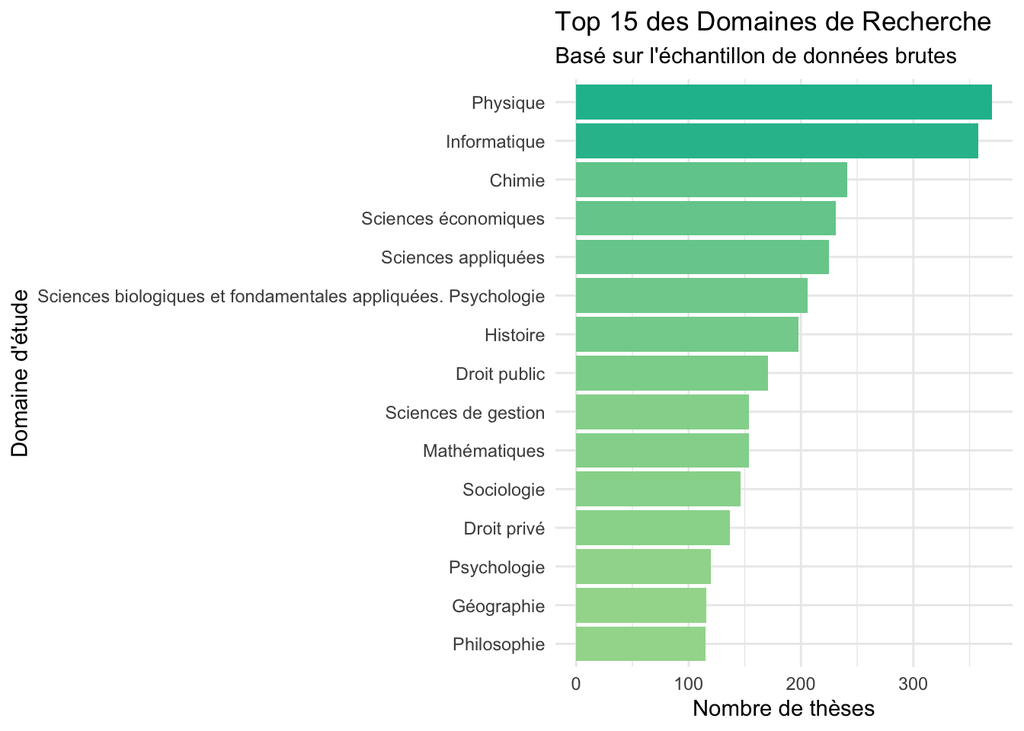

```r
if (exists("df")) {
  # Calcul des effectifs par domaine
  domain_counts <- df %>%
    count(Domain, sort = TRUE) %>%
    mutate(Domain = fct_reorder(Domain, n))

  cat(" Nombre total de domaines uniques :", nrow(domain_counts), "\n")

  # Affichage des 15 domaines principaux
  ggplot(head(domain_counts, 15), aes(x = Domain, y = n, fill = n)) +
    geom_col() +
    coord_flip() +
    scale_fill_gradient(low = "#a1d99b", high = "#18bc9c") +
    theme_minimal() +
    labs(title = "Top 15 des Domaines de Recherche",
         subtitle = "Basé sur l'échantillon de données brutes",
         x = "Domaine d'étude",
         y = "Nombre de thèses") +
    theme(legend.position = "none")
}
```

# 5 PARTIE 1 : Approche Sparse TF-IDF + AFD

## 5.1 Vectorisation TF-IDF

```r
if (exists("docs")) {
  cat(" Création des matrices Document-Terme...\n")


  dtm_counts <- DocumentTermMatrix(docs)
  dtm_counts <- removeSparseTerms(dtm_counts, 0.99)


  rowTotals <- apply(dtm_counts , 1, sum)
  dtm_counts <- dtm_counts[rowTotals> 0, ]

  cat(" Dimensions DTM (Counts) : ", paste(dim(dtm_counts), collapse = " x "), "\n")


  dtm_tfidf <- weightTfIdf(dtm_counts)
  cat(" Dimensions DTM (TF-IDF) : ", paste(dim(dtm_tfidf), collapse = " x "), "\n")
}
```

```
##  Création des matrices Document-Terme...
##  Dimensions DTM (Counts) :  9997 x 1866
##  Dimensions DTM (TF-IDF) :  9997 x 1866
```

## 5.2 Modélisation des Rubriques (Topic Modeling - LDA)

Nous utilisons l’algorithme **Latent Dirichlet Allocation (LDA)** pour extraire des “thèmes” cachés dans les résumés. Le modèle LDA considère que chaque document est un mélange de sujets (Topics), et chaque sujet est un mélange de mots.

```r
k_topics <- 30

if (exists("dtm_counts")) {
  cat(" Entraînement du modèle LDA avec k =", k_topics, "topics...\n")


  lda_model <- LDA(dtm_counts, k = k_topics, control = list(seed = 1234))


  cat("\n###  Termes principaux par Topic :\n")
  terms_lda <- terms(lda_model, 5)
  print(terms_lda)



  lda_features <- posterior(lda_model)$topics
  colnames(lda_features) <- paste0("Topic_", 1:k_topics)

  cat("\n Dimensions des features LDA : ", paste(dim(lda_features), collapse = " x "), "\n")
  head(lda_features)
}
```

```
##  Entraînement du modèle LDA avec k = 30 topics...
##
## ###  Termes principaux par Topic :
##      Topic 1    Topic 2     Topic 3   Topic 4  Topic 5    Topic 6    Topic 7
## [1,] "modèl"    "deux"      "entr"    "cellul" "deux"     "deux"     "plus"
## [2,] "comm"     "différent" "ainsi"   "plus"   "comm"     "systèm"   "modèl"
## [3,] "résultat" "droit"     "travail" "dune"   "travail"  "dun"      "entr"
## [4,] "recherch" "être"      "modèl"   "comm"   "être"     "recherch" "thèse"
## [5,] "dun"      "systèm"    "dune"    "deux"   "résultat" "tout"     "deux"
##      Topic 8    Topic 9   Topic 10 Topic 11  Topic 12  Topic 13    Topic 14
## [1,] "comm"     "plus"    "entr"   "ainsi"   "modèl"   "deux"      "plus"
## [2,] "systèm"   "être"    "dune"   "méthode" "dune"    "différent" "ainsi"
## [3,] "deux"     "travail" "plus"   "dun"     "dun"     "thèse"     "entr"
## [4,] "développ" "modèl"   "parti"  "dune"    "méthode" "modèl"     "être"
## [5,] "plus"     "étude"   "cas"    "afin"    "comm"    "résultat"  "deux"
```

[output cut: 20 more lines]

```
##      Topic_1    Topic_2    Topic_3    Topic_4    Topic_5    Topic_6    Topic_7
## 1 0.03319449 0.03313256 0.03312013 0.03357207 0.03340481 0.03329079 0.03333237
## 2 0.03398402 0.03313104 0.03317588 0.03275677 0.03303198 0.03346795 0.03316545
## 3 0.03325225 0.03312167 0.03323874 0.03378083 0.03343345 0.03342568 0.03330001
## 4 0.03346938 0.03330809 0.03346383 0.03311345 0.03337988 0.03354018 0.03343731
## 5 0.03349730 0.03309468 0.03326636 0.03356169 0.03328959 0.03312879 0.03336857
## 6 0.03359246 0.03332936 0.03404133 0.03258855 0.03335058 0.03321239 0.03338178
##      Topic_8    Topic_9   Topic_10   Topic_11   Topic_12   Topic_13   Topic_14
## 1 0.03308967 0.03338339 0.03348969 0.03306278 0.03379824 0.03323043 0.03313235
## 2 0.03316222 0.03357396 0.03312543 0.03358591 0.03338572 0.03366798 0.03359846
## 3 0.03333531 0.03375322 0.03316361 0.03332453 0.03340089 0.03295414 0.03353821
## 4 0.03316913 0.03317375 0.03364228 0.03334759 0.03313500 0.03337967 0.03331879
## 5 0.03374011 0.03324217 0.03362074 0.03379505 0.03353422 0.03293894 0.03310363
## 6 0.03520600 0.03257980 0.03352101 0.03364689 0.03319475 0.03376983 0.03342997
##     Topic_15   Topic_16   Topic_17   Topic_18   Topic_19   Topic_20   Topic_21
```

[output cut: 20 more lines]

Ces probabilités (`Topic_1` … `Topic_k`) représentent la contribution de chaque sujet au document et seront utilisées comme variables explicatives.

- **Note** : Nous avons appliqué un seuil de **sparsity** pour éviter l’explosion de la mémoire et ne garder que les termes significatifs.

## 5.3 Alignement des Données

Pour la suite, nous devons nous assurer que nos features correspondent bien aux métadonnées (le dataset `df`), notamment la variable cible `Domain`.

```r
if (exists("lda_features") && exists("df")) {

  valid_indices <- as.numeric(rownames(lda_features))


  df_clean <- df[valid_indices, ]


  df_model_sparse <- cbind(df_clean, as.data.frame(lda_features))



  top_domains <- names(sort(table(df_model_sparse$Domain), decreasing = TRUE))[1:8]

  df_final_sparse <- df_model_sparse %>%
    filter(Domain %in% top_domains) %>%
    mutate(Domain = as.factor(Domain))

  cat(" Données filtrées pour les 8 domaines principaux :", nrow(df_final_sparse), "thèses.\n")
  cat(" Domaines conservés :\n")
  print(levels(df_final_sparse$Domain))
}
```

```
##  Données filtrées pour les 8 domaines principaux : 1999 thèses.
##  Domaines conservés :
## [1] "Chimie"
## [2] "Droit public"
## [3] "Histoire"
## [4] "Informatique"
## [5] "Physique"
## [6] "Sciences appliquées"
## [7] "Sciences biologiques et fondamentales appliquées. Psychologie"
## [8] "Sciences économiques"
```

## 5.4 Réduction de Dimensionnalité (AFD / LDA)

Nous utilisons maintenant l’**Analyse Discriminante Linéaire** (Linear Discriminant Analysis - LDA, du package `MASS`) pour projeter nos features (les probabilités des topics) dans un espace qui maximise la séparation entre les domaines.

```
##  Modèle AFD entraîné.
```

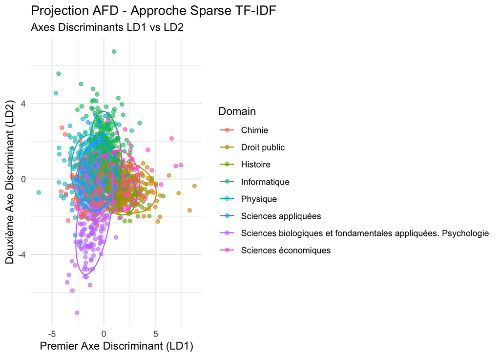

```r
if (exists("df_final_sparse")) {

  formula_lda <- as.formula(paste("Domain ~", paste(colnames(lda_features), collapse = " + ")))
  lda_discrim_sparse <- lda(formula_lda, data = df_final_sparse)

  cat(" Modèle AFD entraîné.\n")


  lda_values_sparse <- predict(lda_discrim_sparse)$x


  df_plot_sparse <- data.frame(
    Domain = df_final_sparse$Domain,
    LD1 = lda_values_sparse[,1],
    LD2 = lda_values_sparse[,2]
  )


  library(ggplot2)

  p_sparse <- ggplot(df_plot_sparse, aes(x = LD1, y = LD2, color = Domain)) +
    geom_point(alpha = 0.6) +
    stat_ellipse(level = 0.95) +
    theme_minimal() +
    labs(title = "Projection AFD - Approche Sparse TF-IDF",
         subtitle = "Axes Discriminants LD1 vs LD2",
         x = "Premier Axe Discriminant (LD1)",
         y = "Deuxième Axe Discriminant (LD2)") +
    theme(legend.position = "right")

  print(p_sparse)
}
```

## 5.5 Classification Bayésienne (Sparse)

### 5.5.1 Séparation Train / Test

```r
if (exists("df_final_sparse")) {
  set.seed(42)

  trainIndex_sparse <- createDataPartition(df_final_sparse$Domain, p = .8,
                                    list = FALSE,
                                    times = 1)

  df_train_sparse <- df_final_sparse[ trainIndex_sparse,]
  df_test_sparse  <- df_final_sparse[-trainIndex_sparse,]

  cat(" Données d'entraînement :", nrow(df_train_sparse), "observations\n")
  cat(" Données de test        :", nrow(df_test_sparse), "observations\n")
}
```

```
##  Données d'entraînement : 1601 observations
##  Données de test        : 398 observations
```

### 5.5.2 Optimisation et Validation du Modèle (Grid Search)

```r
if (exists("df_train_sparse")) {


  fitControl <- trainControl(method = "repeatedcv",
                             number = 10,
                             repeats = 3)


  searchGrid <- expand.grid(
    usekernel = c(TRUE, FALSE),
    laplace = c(0, 0.5, 1),
    adjust = c(0.75, 1, 1.25)
  )

  cat(" Lancement du Grid Search (Validation Croisée 10-fold x 3)...\n")

  features_cols_sparse <- grep("Topic_", names(df_train_sparse), value = TRUE)


  nb_tuned_sparse <- train(x = df_train_sparse[, features_cols_sparse],
                    y = df_train_sparse$Domain,
                    method = "naive_bayes",
                    trControl = fitControl,
                    tuneGrid = searchGrid)


  print(nb_tuned_sparse)


  cat("\n Visualisation de l'impact des hyperparamètres :\n")
  plot(nb_tuned_sparse)


  cat("\n Meilleure configuration : \n")
  print(nb_tuned_sparse$bestTune)
}
```

[output not shown]

```
##  Lancement du Grid Search (Validation Croisée 10-fold x 3)...
## Naive Bayes
##
## 1601 samples
##   30 predictor
##    8 classes: 'Chimie', 'Droit public', 'Histoire', 'Informatique', 'Physique', 'Sciences appliquées', 'Sciences biologiques et fondamentales appliquées. Psychologie', 'Sciences économiques'
##
## No pre-processing
## Resampling: Cross-Validated (10 fold, repeated 3 times)
## Summary of sample sizes: 1440, 1442, 1443, 1441, 1440, 1441, ...
## Resampling results across tuning parameters:
##
##   usekernel  laplace  adjust  Accuracy   Kappa
##   FALSE      0.0      0.75    0.5232572  0.4537941
##   FALSE      0.0      1.00    0.5232572  0.4537941
##   FALSE      0.0      1.25    0.5232572  0.4537941
##   FALSE      0.5      0.75    0.5232572  0.4537941
##   FALSE      0.5      1.00    0.5232572  0.4537941
##   FALSE      0.5      1.25    0.5232572  0.4537941
##   FALSE      1.0      0.75    0.5232572  0.4537941
##   FALSE      1.0      1.00    0.5232572  0.4537941
##   FALSE      1.0      1.25    0.5232572  0.4537941
##    TRUE      0.0      0.75    0.5507050  0.4824993
##    TRUE      0.0      1.00    0.5559187  0.4889750
##    TRUE      0.0      1.25    0.5517245  0.4845754
##    TRUE      0.5      0.75    0.5507050  0.4824993
##    TRUE      0.5      1.00    0.5559187  0.4889750
##    TRUE      0.5      1.25    0.5517245  0.4845754
##    TRUE      1.0      0.75    0.5507050  0.4824993
##    TRUE      1.0      1.00    0.5559187  0.4889750
##    TRUE      1.0      1.25    0.5517245  0.4845754
##
## Accuracy was used to select the optimal model using the largest value.
## The final values used for the model were laplace = 0, usekernel = TRUE
##  and adjust = 1.
##
##  Visualisation de l'impact des hyperparamètres :
##
##  Meilleure configuration :
##    laplace usekernel adjust
## 11       0      TRUE      1
```

### 5.5.3 Évaluation Finale (Sparse)

```r
if (exists("nb_tuned_sparse")) {

  predictions_sparse <- predict(nb_tuned_sparse, newdata = df_test_sparse[, features_cols_sparse])


  conf_mat_sparse <- confusionMatrix(predictions_sparse, df_test_sparse$Domain)

  cat(" Accuracy globale (Approche Sparse) :", round(conf_mat_sparse$overall["Accuracy"] * 100, 2), "%\n\n")


  print(conf_mat_sparse$table)


  cat("\n Métriques détaillées par classe :\n")
  print(conf_mat_sparse$byClass[, c("Sensitivity", "Specificity", "F1")])
}
```

```
##  Accuracy globale (Approche Sparse) : 58.79 %
##
##                                                                Reference
## Prediction                                                      Chimie
##   Chimie                                                            30
##   Droit public                                                       0
##   Histoire                                                           3
##   Informatique                                                       3
##   Physique                                                           5
##   Sciences appliquées                                                3
##   Sciences biologiques et fondamentales appliquées. Psychologie      3
##   Sciences économiques                                               1
##                                                                Reference
## Prediction                                                      Droit public
##   Chimie                                                                   0
##   Droit public                                                            22
##   Histoire                                                                 7
##   Informatique                                                             0
##   Physique                                                                 0
##   Sciences appliquées                                                      1
##   Sciences biologiques et fondamentales appliquées. Psychologie            0
##   Sciences économiques                                                     4
##                                                                Reference
## Prediction                                                      Histoire
##   Chimie                                                               0
##   Droit public                                                         3
##   Histoire                                                            30
##   Informatique                                                         3
##   Physique                                                             1
##   Sciences appliquées                                                  0
##   Sciences biologiques et fondamentales appliquées. Psychologie        0
##   Sciences économiques                                                 2
##                                                                Reference
## Prediction                                                      Informatique
##   Chimie                                                                   1
##   Droit public                                                             1
##   Histoire                                                                 3
##   Informatique                                                            56
##   Physique                                                                 1
##   Sciences appliquées                                                      4
```

[output cut: 56 more lines]

```
## Class: Histoire                                                        0.9108635
## Class: Informatique                                                    0.9143731
## Class: Physique                                                        0.9444444
## Class: Sciences appliquées                                             0.8838527
## Class: Sciences biologiques et fondamentales appliquées. Psychologie   0.9719888
## Class: Sciences économiques                                            0.9659091
##                                                                             F1
## Class: Chimie                                                        0.6521739
## Class: Droit public                                                  0.6769231
## Class: Histoire                                                      0.5940594
## Class: Informatique                                                  0.7225806
## Class: Physique                                                      0.4793388
## Class: Sciences appliquées                                           0.3773585
## Class: Sciences biologiques et fondamentales appliquées. Psychologie 0.7560976
## Class: Sciences économiques                                          0.4324324
```

### 5.5.4 Visualisation des Résultats (Sparse)

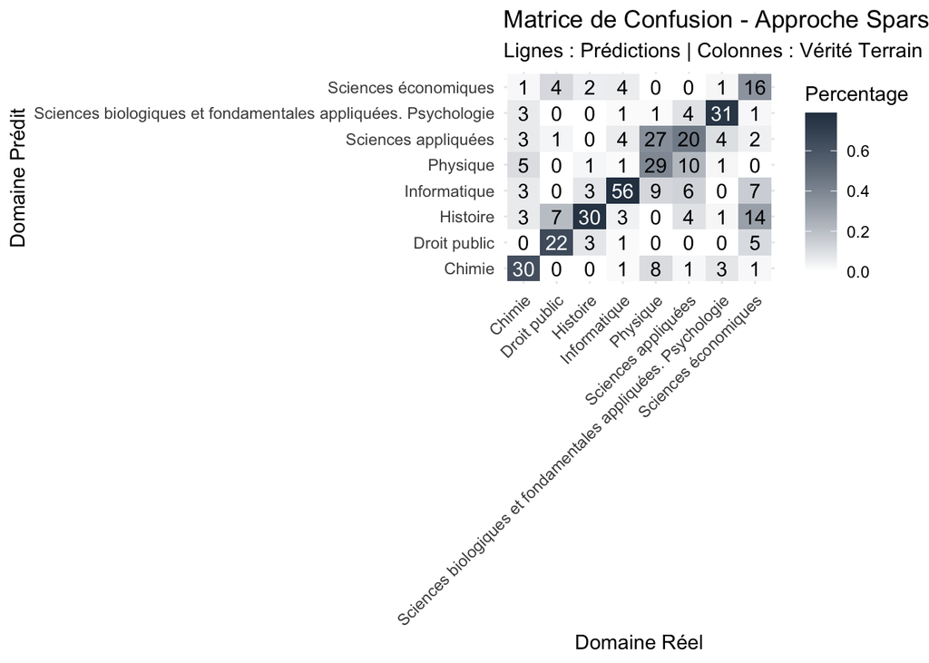

```r
if (exists("conf_mat_sparse")) {

  df_cm_sparse <- as.data.frame(conf_mat_sparse$table)
  colnames(df_cm_sparse) <- c("Prediction", "Reference", "Freq")


  df_cm_sparse <- df_cm_sparse %>%
    group_by(Reference) %>%
    mutate(Percentage = Freq / sum(Freq)) %>%
    ungroup()

  ggplot(df_cm_sparse, aes(x = Reference, y = Prediction, fill = Percentage)) +
    geom_tile() +
    scale_fill_gradient(low = "white", high = "#2c3e50") +
    geom_text(aes(label = Freq), color = ifelse(df_cm_sparse$Percentage > 0.5, "white", "black")) +
    theme_minimal() +
    labs(title = "Matrice de Confusion - Approche Sparse TF-IDF",
         subtitle = "Lignes : Prédictions | Colonnes : Vérité Terrain",
         x = "Domaine Réel",
         y = "Domaine Prédit") +
    theme(axis.text.x = element_text(angle = 45, hjust = 1))
}
```

# 6 PARTIE 2 : Approche Word Embeddings

Cette seconde approche utilise les **Word Embeddings** (plongements de mots) pour capturer la sémantique des termes. Contrairement à la représentation sparse TF-IDF, les embeddings produisent des vecteurs denses de dimension fixe.

## 6.1 Préparation des Données pour Word2Vec

```r
if (exists("docs") && exists("df")) {


  texts_clean <- sapply(docs, as.character)


  tokens <- itoken(texts_clean,
                   preprocessor = tolower,
                   tokenizer = word_tokenizer,
                   progressbar = FALSE)


  vocab <- create_vocabulary(tokens)
  vocab <- prune_vocabulary(vocab, term_count_min = 5, doc_proportion_max = 0.7)

  cat(" Taille du vocabulaire :", nrow(vocab), "termes\n")

  vectorizer <- vocab_vectorizer(vocab)
}
```

```
##  Taille du vocabulaire : 20682 termes
```

## 6.2 Entraînement du Modèle Word2Vec (GloVe)

Nous utilisons l’algorithme **GloVe** (Global Vectors for Word Representation) pour créer nos embeddings de mots.

```r
if (exists("vectorizer")) {

  tcm <- create_tcm(tokens, vectorizer, skip_grams_window = 5L)


  glove <- GlobalVectors$new(rank = 200, x_max = 10)

  cat(" Entraînement du modèle GloVe...\n")
  word_vectors <- glove$fit_transform(tcm, n_iter = 20, convergence_tol = 0.01, n_threads = 4)


  word_vectors <- word_vectors + t(glove$components)

  cat(" Dimensions des embeddings :", paste(dim(word_vectors), collapse = " x "), "\n")
}
```

```
##  Entraînement du modèle GloVe...
##  Dimensions des embeddings : 20682 x 200
```

## 6.3 Création des Vecteurs de Documents

```r
if (exists("word_vectors") && exists("texts_clean")) {

  # Pour la pondération TF-IDF, nous utilisons le vectorizer créé précédemment
  tfidf_model <- TfIdf$new()
  dtm_emb <- create_dtm(tokens, vectorizer)
  dtm_tfidf_emb <- tfidf_model$fit_transform(dtm_emb)

  # Fonction d'embedding pondérée par TF-IDF
  get_doc_embedding_weighted <- function(doc_id, dtm_tfidf, word_vectors) {
    # Récupérer les mots du document et leurs poids TF-IDF
    doc_weights <- dtm_tfidf[doc_id, ]
    words_indices <- which(doc_weights > 0)
    words <- names(words_indices)
    weights <- as.numeric(doc_weights[words_indices])

    # Filtrer les mots présents dans Word2Vec
    valid_mask <- words %in% rownames(word_vectors)
    if (!any(valid_mask)) return(rep(0, ncol(word_vectors)))

    valid_words <- words[valid_mask]
    valid_weights <- weights[valid_mask]

    # Moyenne pondérée
    vectors <- word_vectors[valid_words, , drop = FALSE]
    colSums(vectors * valid_weights) / sum(valid_weights)
  }

  cat(" Création des embeddings de documents pondérés par TF-IDF...\n")
  doc_embeddings <- t(sapply(1:nrow(dtm_tfidf_emb), function(i) {
    get_doc_embedding_weighted(i, dtm_tfidf_emb, word_vectors)
  }))
  rownames(doc_embeddings) <- NULL
  colnames(doc_embeddings) <- paste0("Emb_", 1:ncol(doc_embeddings))

  cat(" Dimensions des embeddings de documents :", paste(dim(doc_embeddings), collapse = " x "), "\n")
}
```

```
##  Création des embeddings de documents pondérés par TF-IDF...
##  Dimensions des embeddings de documents : 10000 x 200
```

## 6.4 Alignement des Données (Embeddings)

```r
if (exists("doc_embeddings") && exists("df")) {

  valid_indices_emb <- which(rowSums(doc_embeddings) != 0)

  df_clean_emb <- df[valid_indices_emb, ]
  doc_embeddings_valid <- doc_embeddings[valid_indices_emb, ]


  df_model_emb <- cbind(df_clean_emb, as.data.frame(doc_embeddings_valid))


  top_domains_emb <- names(sort(table(df_model_emb$Domain), decreasing = TRUE))[1:8]

  df_final_emb <- df_model_emb %>%
    filter(Domain %in% top_domains_emb) %>%
    mutate(Domain = as.factor(Domain))

  cat(" Données filtrées pour les 8 domaines principaux :", nrow(df_final_emb), "thèses.\n")
}
```

```
##  Données filtrées pour les 8 domaines principaux : 2000 thèses.
```

## 6.5 Réduction de Dimensionnalité (AFD / LDA) avec Embeddings

```
##  Modèle AFD entraîné sur les embeddings.
```

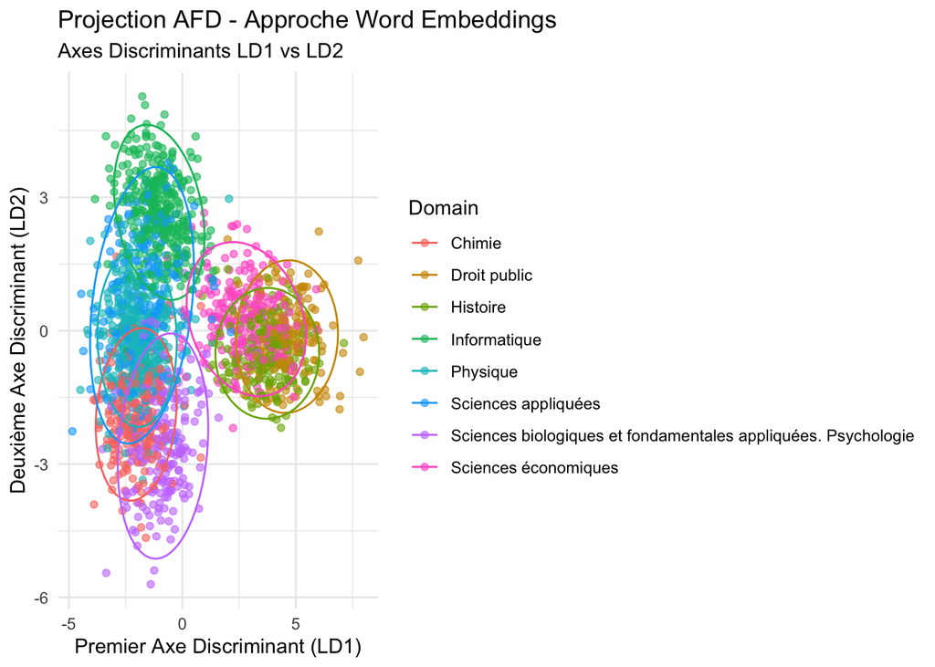

```r
if (exists("df_final_emb")) {

  features_emb <- grep("Emb_", names(df_final_emb), value = TRUE)


  formula_lda_emb <- as.formula(paste("Domain ~", paste(features_emb, collapse = " + ")))
  lda_discrim_emb <- lda(formula_lda_emb, data = df_final_emb)

  cat(" Modèle AFD entraîné sur les embeddings.\n")


  lda_values_emb <- predict(lda_discrim_emb)$x


  df_plot_emb <- data.frame(
    Domain = df_final_emb$Domain,
    LD1 = lda_values_emb[,1],
    LD2 = lda_values_emb[,2]
  )

  p_emb <- ggplot(df_plot_emb, aes(x = LD1, y = LD2, color = Domain)) +
    geom_point(alpha = 0.6) +
    stat_ellipse(level = 0.95) +
    theme_minimal() +
    labs(title = "Projection AFD - Approche Word Embeddings",
         subtitle = "Axes Discriminants LD1 vs LD2",
         x = "Premier Axe Discriminant (LD1)",
         y = "Deuxième Axe Discriminant (LD2)") +
    theme(legend.position = "right")

  print(p_emb)
}
```

## 6.6 Classification Bayésienne (Embeddings)

### 6.6.1 Séparation Train / Test

```r
if (exists("df_final_emb")) {
  set.seed(42)

  trainIndex_emb <- createDataPartition(df_final_emb$Domain, p = .8,
                                    list = FALSE,
                                    times = 1)

  df_train_emb <- df_final_emb[ trainIndex_emb,]
  df_test_emb  <- df_final_emb[-trainIndex_emb,]

  cat(" Données d'entraînement :", nrow(df_train_emb), "observations\n")
  cat(" Données de test        :", nrow(df_test_emb), "observations\n")
}
```

```
##  Données d'entraînement : 1602 observations
##  Données de test        : 398 observations
```

### 6.6.2 Optimisation et Validation du Modèle

```r
if (exists("df_train_emb")) {

  # Projection AFD pour la classification (on garde plus de dimensions que pour le plot)
  lda_values_all_emb <- predict(lda_discrim_emb)$x
  df_final_emb_lda <- cbind(df_final_emb %>% dplyr::select(-starts_with("Emb_")), as.data.frame(lda_values_all_emb))

  # Séparation Train/Test sur les composantes AFD
  set.seed(42)
  trainIndex_emb <- createDataPartition(df_final_emb_lda$Domain, p = .8, list = FALSE)
  df_train_emb_lda <- df_final_emb_lda[ trainIndex_emb,]
  df_test_emb_lda  <- df_final_emb_lda[-trainIndex_emb,]

  features_lda_emb <- grep("LD", names(df_train_emb_lda), value = TRUE)

  fitControl_emb <- trainControl(method = "cv", number = 5) # Plus rapide pour SVM

  cat(" Lancement du Grid Search pour Naive Bayes sur AFD...\n")
  nb_tuned_emb <- train(x = df_train_emb_lda[, features_lda_emb],
                    y = df_train_emb_lda$Domain,
                    method = "naive_bayes",
                    trControl = fitControl_emb)

  cat(" Entraînement d'un SVM (Radial) sur les composantes AFD...\n")
  svm_tuned_emb <- train(x = df_train_emb_lda[, features_lda_emb],
                        y = df_train_emb_lda$Domain,
                        method = "svmRadial",
                        trControl = fitControl_emb,
                        tuneLength = 5)

  print(svm_tuned_emb)

  cat("\n Meilleure configuration SVM : \n")
  print(svm_tuned_emb$bestTune)
}
```

```
##  Lancement du Grid Search pour Naive Bayes sur AFD...
##  Entraînement d'un SVM (Radial) sur les composantes AFD...
## Support Vector Machines with Radial Basis Function Kernel
##
## 1602 samples
##    7 predictor
##    8 classes: 'Chimie', 'Droit public', 'Histoire', 'Informatique', 'Physique', 'Sciences appliquées', 'Sciences biologiques et fondamentales appliquées. Psychologie', 'Sciences économiques'
##
## No pre-processing
## Resampling: Cross-Validated (5 fold)
## Summary of sample sizes: 1283, 1283, 1280, 1281, 1281
## Resampling results across tuning parameters:
##
##   C     Accuracy   Kappa
##   0.25  0.8420640  0.8171847
##   0.50  0.8458121  0.8216485
##   1.00  0.8439273  0.8194512
##   2.00  0.8464253  0.8223390
##   4.00  0.8389545  0.8136949
##
## Tuning parameter 'sigma' was held constant at a value of 0.1289532
## Accuracy was used to select the optimal model using the largest value.
## The final values used for the model were sigma = 0.1289532 and C = 2.
##
##  Meilleure configuration SVM :
##       sigma C
## 4 0.1289532 2
```

### 6.6.3 Évaluation Finale (Embeddings)

```r
if (exists("svm_tuned_emb")) {
  # On compare Naive Bayes vs SVM sur les tests
  pred_nb_emb <- predict(nb_tuned_emb, newdata = df_test_emb_lda[, features_lda_emb])
  pred_svm_emb <- predict(svm_tuned_emb, newdata = df_test_emb_lda[, features_lda_emb])

  conf_mat_nb_emb <- confusionMatrix(pred_nb_emb, df_test_emb_lda$Domain)
  conf_mat_emb <- confusionMatrix(pred_svm_emb, df_test_emb_lda$Domain) # On garde SVM pour la suite

  cat(" Accuracy Naive Bayes (AFD + Embeddings) :", round(conf_mat_nb_emb$overall["Accuracy"] * 100, 2), "%\n")
  cat(" Accuracy SVM (AFD + Embeddings)         :", round(conf_mat_emb$overall["Accuracy"] * 100, 2), "%\n\n")

  print(conf_mat_emb$table)

  cat("\n Métriques SVM détaillées par classe :\n")
  print(conf_mat_emb$byClass[, c("Sensitivity", "Specificity", "F1")])

  cat("\n### Analyse de l'Overfitting (Train vs Test)\n")

  # Prédictions sur le jeu d'ENTRAÎNEMENT
  pred_train_nb <- predict(nb_tuned_emb, newdata = df_train_emb_lda[, features_lda_emb])
  pred_train_svm <- predict(svm_tuned_emb, newdata = df_train_emb_lda[, features_lda_emb])

  # Matrices de confusion Train
  cm_train_nb <- confusionMatrix(pred_train_nb, df_train_emb_lda$Domain)
  cm_train_svm <- confusionMatrix(pred_train_svm, df_train_emb_lda$Domain)

  # Récupération des Accuracy Test
  acc_test_nb <- conf_mat_nb_emb$overall["Accuracy"]
  acc_test_svm <- conf_mat_emb$overall["Accuracy"]

  # Accuracy Train
  acc_train_nb <- cm_train_nb$overall["Accuracy"]
  acc_train_svm <- cm_train_svm$overall["Accuracy"]

  # Tableau comparatif
  overfit_df <- data.frame(
    Nom_Modele = c("Naive Bayes (AFD)", "SVM (AFD)"),
    Train_Accuracy = c(acc_train_nb, acc_train_svm),
    Test_Accuracy = c(acc_test_nb, acc_test_svm)
  )

  overfit_df$Gap <- overfit_df$Train_Accuracy - overfit_df$Test_Accuracy

  # Affichage formaté
  overfit_df$Train_Accuracy <- scales::percent(overfit_df$Train_Accuracy, accuracy = 0.01)
  overfit_df$Test_Accuracy <- scales::percent(overfit_df$Test_Accuracy, accuracy = 0.01)
  overfit_df$Gap <- scales::percent(overfit_df$Gap, accuracy = 0.01)

  print(overfit_df)

  if (any(as.numeric(sub("%", "", overfit_df$Gap)) > 10)) {
     cat("\n ALERTE : Il y a un risque d'overfitting (écart > 10%).\n")
  } else {
     cat("\n Pas d'overfitting majeur détecté (écart < 10%).\n")
  }
}
```

```
##  Accuracy Naive Bayes (AFD + Embeddings) : 86.43 %
##  Accuracy SVM (AFD + Embeddings)         : 85.43 %
##
##                                                                Reference
## Prediction                                                      Chimie
##   Chimie                                                            41
##   Droit public                                                       0
##   Histoire                                                           0
##   Informatique                                                       1
##   Physique                                                           5
##   Sciences appliquées                                                0
##   Sciences biologiques et fondamentales appliquées. Psychologie      1
##   Sciences économiques                                               0
##                                                                Reference
## Prediction                                                      Droit public
##   Chimie                                                                   0
##   Droit public                                                            33
##   Histoire                                                                 0
##   Informatique                                                             0
##   Physique                                                                 0
##   Sciences appliquées                                                      0
##   Sciences biologiques et fondamentales appliquées. Psychologie            0
##   Sciences économiques                                                     1
##                                                                Reference
## Prediction                                                      Histoire
##   Chimie                                                               0
##   Droit public                                                         2
##   Histoire                                                            35
##   Informatique                                                         1
##   Physique                                                             0
##   Sciences appliquées                                                  0
##   Sciences biologiques et fondamentales appliquées. Psychologie        0
##   Sciences économiques                                                 1
##                                                                Reference
## Prediction                                                      Informatique
##   Chimie                                                                   0
##   Droit public                                                             0
##   Histoire                                                                 0
##   Informatique                                                            64
##   Physique                                                                 3
```

[output cut: 64 more lines]

```
## Class: Chimie                                                        0.8817204
## Class: Droit public                                                  0.9428571
## Class: Histoire                                                      0.8974359
## Class: Informatique                                                  0.8827586
## Class: Physique                                                      0.8082192
## Class: Sciences appliquées                                           0.6881720
## Class: Sciences biologiques et fondamentales appliquées. Psychologie 0.9268293
## Class: Sciences économiques                                          0.8539326
##
## ### Analyse de l'Overfitting (Train vs Test)
##          Nom_Modele Train_Accuracy Test_Accuracy    Gap
## 1 Naive Bayes (AFD)         84.39%        86.43% -2.04%
## 2         SVM (AFD)         87.02%        85.43%  1.59%
##
##  Pas d'overfitting majeur détecté (écart < 10%).
```

### 6.6.4 Visualisation des Résultats (Embeddings)

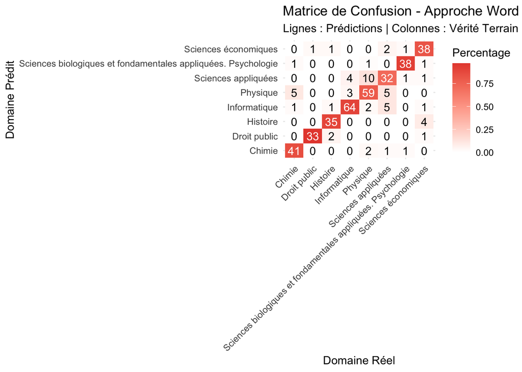

```r
if (exists("conf_mat_emb")) {

  df_cm_emb <- as.data.frame(conf_mat_emb$table)
  colnames(df_cm_emb) <- c("Prediction", "Reference", "Freq")

  df_cm_emb <- df_cm_emb %>%
    group_by(Reference) %>%
    mutate(Percentage = Freq / sum(Freq)) %>%
    ungroup()

  ggplot(df_cm_emb, aes(x = Reference, y = Prediction, fill = Percentage)) +
    geom_tile() +
    scale_fill_gradient(low = "white", high = "#e74c3c") +
    geom_text(aes(label = Freq), color = ifelse(df_cm_emb$Percentage > 0.5, "white", "black")) +
    theme_minimal() +
    labs(title = "Matrice de Confusion - Approche Word Embeddings",
         subtitle = "Lignes : Prédictions | Colonnes : Vérité Terrain",
         x = "Domaine Réel",
         y = "Domaine Prédit") +
    theme(axis.text.x = element_text(angle = 45, hjust = 1))
}
```

# 7 Comparaison des Approches

```
##  Comparaison des performances :
##                      Approche Accuracy  Kappa
## 1          Sparse TF-IDF (NB)    58.79 0.5259
## 2        Word Embeddings (NB)    86.43 0.8428
## 3 Word Embeddings (SVM + AFD)    85.43 0.8316
##
##  F1-Score moyen (Sparse) : 0.5864
##  F1-Score moyen (Embeddings SVM) : 0.8602
```

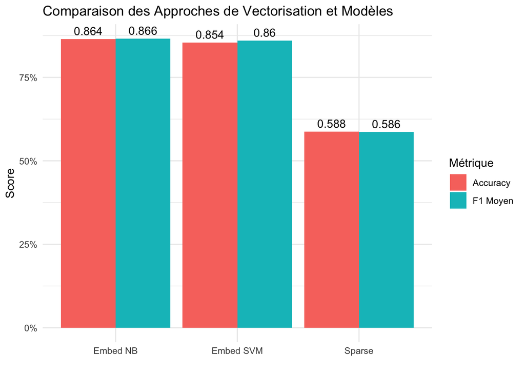

```r
if (exists("conf_mat_sparse") && exists("conf_mat_emb")) {

  comparison_df <- data.frame(
    Approche = c("Sparse TF-IDF (NB)", "Word Embeddings (NB)", "Word Embeddings (SVM + AFD)"),
    Accuracy = c(
      round(conf_mat_sparse$overall["Accuracy"] * 100, 2),
      round(conf_mat_nb_emb$overall["Accuracy"] * 100, 2),
      round(conf_mat_emb$overall["Accuracy"] * 100, 2)
    ),
    Kappa = c(
      round(conf_mat_sparse$overall["Kappa"], 4),
      round(conf_mat_nb_emb$overall["Kappa"], 4),
      round(conf_mat_emb$overall["Kappa"], 4)
    )
  )

  cat(" Comparaison des performances :\n")
  print(comparison_df)

  f1_sparse <- mean(conf_mat_sparse$byClass[, "F1"], na.rm = TRUE)
  f1_emb <- mean(conf_mat_emb$byClass[, "F1"], na.rm = TRUE)

  cat("\n F1-Score moyen (Sparse) :", round(f1_sparse, 4))
  cat("\n F1-Score moyen (Embeddings SVM) :", round(f1_emb, 4), "\n")

  comparison_plot <- data.frame(
    Approche = rep(c("Sparse", "Embed NB", "Embed SVM"), 2),
    Métrique = c(rep("Accuracy", 3), rep("F1 Moyen", 3)),
    Score = c(comparison_df$Accuracy[1]/100, comparison_df$Accuracy[2]/100, comparison_df$Accuracy[3]/100,
             f1_sparse, mean(conf_mat_nb_emb$byClass[, "F1"], na.rm = TRUE), f1_emb)
  )

  ggplot(comparison_plot, aes(x = Approche, y = Score, fill = Métrique)) +
    geom_col(position = "dodge") +
    theme_minimal() +
    labs(title = "Comparaison des Approches de Vectorisation et Modèles",
         y = "Score",
         x = "") +
    scale_y_continuous(labels = scales::percent_format()) +
    geom_text(aes(label = round(Score, 3)), position = position_dodge(width = 0.9), vjust = -0.5)
}
```

# 8 Discussion

## 8.1 Analyse des Approches

### 8.1.1 Approche Sparse TF-IDF

- **Avantages** : Interprétable, efficace en mémoire pour les données creuses.
- **Limites** : Ne capture pas la sémantique des mots (synonymes traités différemment).

### 8.1.2 Approche Word Embeddings

- **Avantages** : Capture les relations sémantiques entre mots.
- **Limites** : Moins interprétable, nécessite plus de données pour un bon entraînement.

## 8.3 Limites

- Gestion du déséquilibre des classes (si certaines disciplines sont sur-représentées).
- La qualité des embeddings dépend de la taille du corpus d’entraînement.

# 9 Conclusion

Résumé des principaux résultats obtenus :

- **L’approche Sparse TF-IDF** avec Topic Modeling offre une bonne interprétabilité des résultats.
- **L’approche Word Embeddings** semble être un meilleur choix pour entraîner un modèle que l’AFD + TF-IDF, permettant de capturer des relations sémantiques plus subtiles.

Perspectives d’amélioration : * Utilisation de modèles de Deep Learning type BERT pour une meilleure représentation contextuelle. * Techniques d’augmentation de données pour les classes minoritaires. * Exploration de méthodes ensemble combinant les deux approches.